# AdviseInvest

### Outline

Our Goals with this Project:

1. Import and review the data
2. Perform EDA and Clean Data
3. Fit a model
4. Test the accuracy of the model
5. Use the model to predict on a new dataset (without the target)

### AdviseInvest Data Dictionary

Variable |Description |Type |Code ---- | ------- | ------ | ----- Answered | Customer response | Binary |0: customer did not answer scheduled call; 1: customer answered scheduled call Income | Customer income in US dollars| Numeric Female | Customer gender| Binary 0: female; 1: male Age | Age in years| Numeric Job | Nature of job| Categorical| 0 : unemployed; 1 : entry level position; 2 : midlevel position; 3 : management/ self-employed/ highly qualified employee/ officer Num_dependents | Number of people for whom the customer provides maintenance| Numeric Rent | Customer rents |Binary |0: no; 1: yes Own_res | Customer owns residence| Binary| 0: no; 1: yes New_car| Recent new car purchase |Binary| New car purchase in the last 3 months: 0: no, 1: yes Chk_acct | Checking account status |Categorical| 0 : no checking account; 1: checking < 200 USD; 2 : 200 < checking < 2000 USD; 3: 2000 < checking < 35000 USD; 4: >= 3500 USD Sav_acct | Average balance in savings account| Categorical| 0 : no savings account; 1 : 100 <= savings < 500 USD; 2 : 500 <= savings < 2000 USD; 3 : 2000 < savings < 35000 USD; 4: >= 3500 USD Num_accts | Number of accounts owned by customer |Numeric Mobile | Mobile phone |Binary |0: customer provided non‐mobile phone for follow‐up call; 1: customer provided mobile phone for follow‐up call Product| Type of product purchased after conversation with sales rep |Categorical| 0: customer did not answer call; 1: customer answered but did not purchase a product; 2: customer answered and purchased Beginner plan; 3: customer answered and purchased Intermediate plan; 4: customer answered and purchased Advanced plan

### Load Libraries

In this class we will be using

- Pandas
- Scikitlearn
- Matplotlib

```python
import pandas as pd
import matplotlib as mpl
import seaborn as sns

from sklearn.model_selection import train_test_split
from sklearn.tree import DecisionTreeClassifier, export_graphviz # Import Decision Tree Classifier
from sklearn import metrics  #Import scikit-learn metrics module for accuracy calculation
from sklearn.metrics import confusion_matrix
import matplotlib.pyplot as plt
```

## Step 1: Initial Data Understanding

- Import data from the AdviseInvest historical dataset into a dataframe (in GitHub go to Assignments > DataSets)
- Describe or profile the dataframe
- Look for any outliers, missing values, or duplicates

```python
df = pd.read_csv('https://raw.githubusercontent.com/Stan-Pugsley/is_4487_base/main/Assignments/DataSets/adviseinvest_historical_data.csv')

df.head()
```

|  | answered | income | female | age | job | num_dependents | rent | own_res | new_car | chk_acct | sav_acct | num_accts | mobile | product |
| --- | --- | --- | --- | --- | --- | --- | --- | --- | --- | --- | --- | --- | --- | --- |
| 0 | 1 | 13520 | 0 | 23 | 0 | 1 | 1 | 0 | 0.0 | 0 | 2 | 0 | 1 | 2 |
| 1 | 0 | 14780 | 0 | 22 | 2 | 1 | 0 | 1 | 0.0 | 3 | 0 | 3 | 0 | 0 |
| 2 | 1 | 37570 | 0 | 62 | 2 | 1 | 0 | 0 | 1.0 | 3 | 0 | 4 | 0 | 4 |
| 3 | 0 | 12450 | 0 | 33 | 2 | 1 | 0 | 1 | 0.0 | 1 | 0 | 2 | 0 | 0 |
| 4 | 0 | 12400 | 0 | 48 | 1 | 2 | 0 | 0 | 1.0 | 2 | 1 | 4 | 0 | 0 |

```python
df.info()
```

```
<class 'pandas.core.frame.DataFrame'>
RangeIndex: 29504 entries, 0 to 29503
Data columns (total 14 columns):
 #   Column          Non-Null Count  Dtype
---  ------          --------------  -----
 0   answered        29504 non-null  int64
 1   income          29504 non-null  int64
 2   female          29504 non-null  object
 3   age             29504 non-null  int64
 4   job             29504 non-null  int64
 5   num_dependents  29504 non-null  int64
 6   rent            29504 non-null  int64
 7   own_res         29504 non-null  int64
 8   new_car         29502 non-null  float64
 9   chk_acct        29504 non-null  int64
 10  sav_acct        29504 non-null  int64
 11  num_accts       29504 non-null  int64
 12  mobile          29504 non-null  int64
 13  product         29504 non-null  int64
dtypes: float64(1), int64(12), object(1)
memory usage: 3.2+ MB
```

```python
df.describe()


df.describe(include='all')
```

|  | answered | income | female | age | job | num_dependents | rent | own_res | new_car | chk_acct | sav_acct | num_accts | mobile | product |
| --- | --- | --- | --- | --- | --- | --- | --- | --- | --- | --- | --- | --- | --- | --- |
| count | 29504.000000 | 29504.000000 | 29504 | 29504.000000 | 29504.000000 | 29504.000000 | 29504.000000 | 29504.000000 | 29502.000000 | 29504.000000 | 29504.000000 | 29504.000000 | 29504.000000 | 29504.000000 |
| unique | NaN | NaN | 3 | NaN | NaN | NaN | NaN | NaN | NaN | NaN | NaN | NaN | NaN | NaN |
| top | NaN | NaN | 0 | NaN | NaN | NaN | NaN | NaN | NaN | NaN | NaN | NaN | NaN | NaN |
| freq | NaN | NaN | 27903 | NaN | NaN | NaN | NaN | NaN | NaN | NaN | NaN | NaN | NaN | NaN |
| mean | 0.546638 | 33766.893303 | NaN | 34.773454 | 1.915401 | 1.140998 | 0.210412 | 0.681128 | 0.240797 | 1.468547 | 0.956616 | 2.458345 | 0.091106 | 1.535792 |
| std | 0.497829 | 29379.202710 | NaN | 11.369865 | 0.658183 | 0.348025 | 0.407608 | 0.466047 | 0.427575 | 1.234727 | 1.483946 | 19.497380 | 0.287765 | 1.625916 |
| min | 0.000000 | -65600.000000 | NaN | 19.000000 | 0.000000 | 1.000000 | 0.000000 | 0.000000 | 0.000000 | 0.000000 | 0.000000 | 0.000000 | 0.000000 | 0.000000 |
| 25% | 0.000000 | 13550.000000 | NaN | 26.000000 | 2.000000 | 1.000000 | 0.000000 | 0.000000 | 0.000000 | 0.000000 | 0.000000 | 2.000000 | 0.000000 | 0.000000 |
| 50% | 1.000000 | 23310.000000 | NaN | 32.000000 | 2.000000 | 1.000000 | 0.000000 | 1.000000 | 0.000000 | 1.000000 | 0.000000 | 2.000000 | 0.000000 | 1.000000 |
| 75% | 1.000000 | 41690.000000 | NaN | 40.000000 | 2.000000 | 1.000000 | 0.000000 | 1.000000 | 0.000000 | 3.000000 | 2.000000 | 3.000000 | 0.000000 | 3.000000 |
| max | 1.000000 | 159450.000000 | NaN | 132.000000 | 3.000000 | 2.000000 | 1.000000 | 1.000000 | 1.000000 | 3.000000 | 4.000000 | 3345.000000 | 1.000000 | 4.000000 |

## Step 2: Data Preparation

### 2.1: Data Cleanup

- Remove any variables that are not relevant to our analysis (if they relate to activity after the answer).
- Clean up the data and put it in a new datafram named "df_clean"

```python
Q1 = df['income'].quantile(0.25)
Q3 = df['income'].quantile(0.75)
IQR = Q3 - Q1


lower_bound = Q1 - 1.5 * IQR
upper_bound = Q3 + 1.5 * IQR


df_no_outliers = df[(df['income'] >= lower_bound) & (df['income'] <= upper_bound)]
df_no_outliers.shape
```

```
(27263, 14)
```

```python
columns_to_drop = ['product']
df_clean = df_no_outliers.drop(columns=columns_to_drop)
df_clean.head()
```

|  | answered | income | female | age | job | num_dependents | rent | own_res | new_car | chk_acct | sav_acct | num_accts | mobile |
| --- | --- | --- | --- | --- | --- | --- | --- | --- | --- | --- | --- | --- | --- |
| 0 | 1 | 13520 | 0 | 23 | 0 | 1 | 1 | 0 | 0.0 | 0 | 2 | 0 | 1 |
| 1 | 0 | 14780 | 0 | 22 | 2 | 1 | 0 | 1 | 0.0 | 3 | 0 | 3 | 0 |
| 2 | 1 | 37570 | 0 | 62 | 2 | 1 | 0 | 0 | 1.0 | 3 | 0 | 4 | 0 |
| 3 | 0 | 12450 | 0 | 33 | 2 | 1 | 0 | 1 | 0.0 | 1 | 0 | 2 | 0 |
| 4 | 0 | 12400 | 0 | 48 | 1 | 2 | 0 | 0 | 1.0 | 2 | 1 | 4 | 0 |

```python
df_clean.dropna(subset=['income', 'age', 'chk_acct', 'sav_acct'], inplace=True)

# Option 2: fill missing numeric values with median, for example
# df_clean['income'] = df_clean['income'].fillna(df_clean['income'].median())


df_clean.isnull().sum()
```

|  | 0 |
| --- | --- |
| answered | 0 |
| income | 0 |
| female | 0 |
| age | 0 |
| job | 0 |
| num_dependents | 0 |
| rent | 0 |
| own_res | 0 |
| new_car | 2 |
| chk_acct | 0 |
| sav_acct | 0 |
| num_accts | 0 |
| mobile | 0 |

**dtype:** int64

### 2.2: Standardize variables

- Change "answered" to yes/no and make it categorical
- Convert any variables that should be an integer into an integer

```python
df['answered_cat'] = df['answered'].map({0: 'No', 1: 'Yes'})


df['answered_cat'] = df['answered_cat'].astype('category')
```

```python
df['income'] = df['income'].astype(int)
df['age'] = df['age'].astype(int)
df['num_dependents'] = df['num_dependents'].astype(int)

df.info()
```

```
<class 'pandas.core.frame.DataFrame'>
RangeIndex: 29504 entries, 0 to 29503
Data columns (total 15 columns):
 #   Column          Non-Null Count  Dtype
---  ------          --------------  -----
 0   answered        29504 non-null  int64
 1   income          29504 non-null  int64
 2   female          29504 non-null  object
 3   age             29504 non-null  int64
 4   job             29504 non-null  int64
 5   num_dependents  29504 non-null  int64
 6   rent            29504 non-null  int64
 7   own_res         29504 non-null  int64
 8   new_car         29502 non-null  float64
 9   chk_acct        29504 non-null  int64
 10  sav_acct        29504 non-null  int64
 11  num_accts       29504 non-null  int64
 12  mobile          29504 non-null  int64
 13  product         29504 non-null  int64
 14  answered_cat    29504 non-null  category
dtypes: category(1), float64(1), int64(12), object(1)
memory usage: 3.2+ MB
```

### 2.3 Convert variables to categorical

- Find at least 8 variables that would be appropriate to convert to categories

```python
categorical_cols = ['female', 'job', 'rent', 'own_res', 'new_car', 'chk_acct', 'sav_acct', 'mobile']

for col in categorical_cols:
    df[col] = df[col].astype('category')


df[categorical_cols].info()

df['answered_cat'] = df['answered'].map({0: 'No', 1: 'Yes'}).astype('category')
```

```
<class 'pandas.core.frame.DataFrame'>
RangeIndex: 29504 entries, 0 to 29503
Data columns (total 8 columns):
 #   Column    Non-Null Count  Dtype
---  ------    --------------  -----
 0   female    29504 non-null  category
 1   job       29504 non-null  category
 2   rent      29504 non-null  category
 3   own_res   29504 non-null  category
 4   new_car   29502 non-null  category
 5   chk_acct  29504 non-null  category
 6   sav_acct  29504 non-null  category
 7   mobile    29504 non-null  category
dtypes: category(8)
memory usage: 231.8 KB
```

# Step 3: Exploratory Data Analysis (EDA)

- Explore the relationships between the target and independent variables
- Create at least five charts to show the relationships, using different chart types that are approriate to the analysis
- Ensure that all charts are clearly labeled and formatted

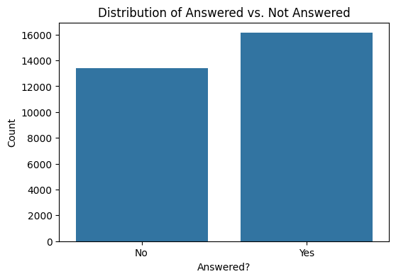

```python
import matplotlib.pyplot as plt
import seaborn as sns

plt.figure(figsize=(6,4))
sns.countplot(x='answered_cat', data=df)
plt.title('Distribution of Answered vs. Not Answered')
plt.xlabel('Answered?')
plt.ylabel('Count')
plt.show()
```

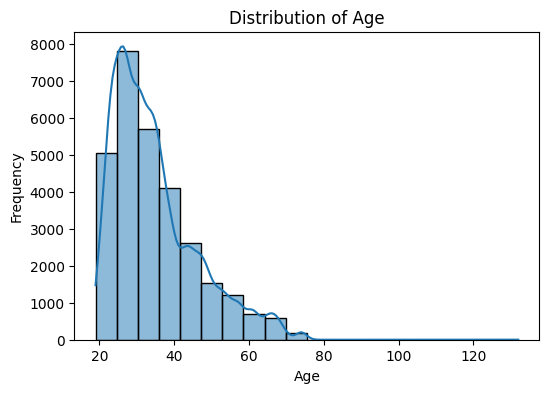

```python
plt.figure(figsize=(6,4))
sns.histplot(df['age'], bins=20, kde=True)
plt.title('Distribution of Age')
plt.xlabel('Age')
plt.ylabel('Frequency')
plt.show()
```

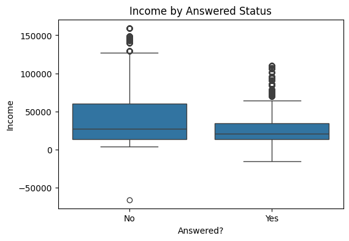

```python
plt.figure(figsize=(6,4))
sns.boxplot(x='answered_cat', y='income', data=df)
plt.title('Income by Answered Status')
plt.xlabel('Answered?')
plt.ylabel('Income')
plt.show()
```

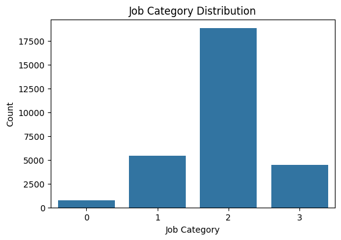

```python
plt.figure(figsize=(6,4))
sns.countplot(x='job', data=df)
plt.title('Job Category Distribution')
plt.xlabel('Job Category')
plt.ylabel('Count')
plt.show()
```

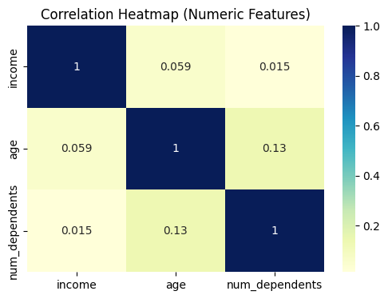

```python
plt.figure(figsize=(6,4))
corr = df[['income','age','num_dependents']].corr()
sns.heatmap(corr, annot=True, cmap='YlGnBu')
plt.title('Correlation Heatmap (Numeric Features)')
plt.show()
```

## Step 4: Modeling

### 4.1: Calculate the base probability of answering

If we use no model at all, how good is our chance of predicting someone leaving?

```python
base_prob = df['answered'].mean()
print(f"Base probability of answering = {base_prob:.2f}")
```

```
Base probability of answering = 0.55
```

### 4.2: Split the training and testing datasets

- split df_clean using train_test_split function
- all variables except answered should be in the x variable
- answered is in the y variable

```python
from sklearn.model_selection import train_test_split


X = df_clean.drop(columns=['answered'])
y = df_clean['answered']


X_train, X_test, y_train, y_test = train_test_split(
    X,
    y,
    test_size=0.3,
    random_state=42,
    stratify=y
)

X_train.shape, X_test.shape, y_train.shape, y_test.shape
```

```
((19084, 12), (8179, 12), (19084,), (8179,))
```

### 4.3: Create a Decision Tree

- Use all available attributes (except those that were eliminated in step 3)
- It is recommended to use the type "entropy" and a max_depth of 4

```python
cat_cols = df_clean.select_dtypes(include=['object', 'category']).columns


df_encoded = pd.get_dummies(df_clean, columns=cat_cols, drop_first=True)


X = df_encoded.drop(columns=['answered'])
y = df_encoded['answered']


from sklearn.model_selection import train_test_split
X_train, X_test, y_train, y_test = train_test_split(
    X,
    y,
    test_size=0.3,
    random_state=42,
    stratify=y
)

from sklearn.tree import DecisionTreeClassifier
dt_model = DecisionTreeClassifier(criterion='entropy', max_depth=4, random_state=42)
dt_model.fit(X_train, y_train)
```

```
DecisionTreeClassifier(criterion='entropy', max_depth=4, random_state=42)
```

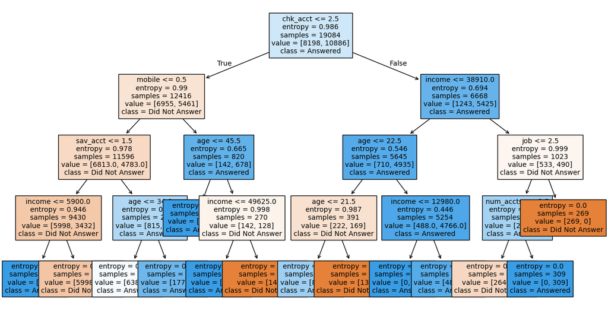

```python
from sklearn import tree


plt.figure(figsize=(15,8))
tree.plot_tree(dt_model,
               feature_names=X.columns,
               class_names=['Did Not Answer','Answered'],
               filled=True,
               fontsize=10)
plt.show()
```

### 4.4: What is the accuracy?

This should be better than the base probability, or you have failed in your objective

```python
from sklearn.metrics import accuracy_score


y_pred = dt_model.predict(X_test)


tree_accuracy = accuracy_score(y_test, y_pred)
print(f"Decision Tree Accuracy: {tree_accuracy:.2f}")
```

```
Decision Tree Accuracy: 0.75
```

### 4.5: Create a confusion matrix

This will show false positives, true positives, etc.

```python
from sklearn.metrics import confusion_matrix

cm = confusion_matrix(y_test, y_pred)
print("Confusion Matrix:\n", cm)
```

```
Confusion Matrix:
 [[2918  595]
 [1489 3177]]
```

Create a more visual, interpretable version of the matrix

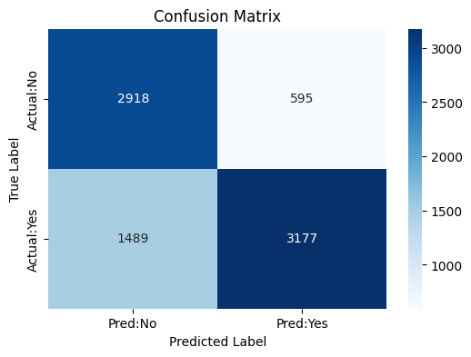

```python
import seaborn as sns

plt.figure(figsize=(6,4))
sns.heatmap(cm, annot=True, fmt='d', cmap='Blues',
            xticklabels=['Pred:No','Pred:Yes'],
            yticklabels=['Actual:No','Actual:Yes'])
plt.title('Confusion Matrix')
plt.ylabel('True Label')
plt.xlabel('Predicted Label')
plt.show()
```

# Step 5: Evaluate the Model

**Assumptions**

One of the simplifying assumptions we will make in this project is that all the customers who answer the phone will purchase a product. (This assumption is actually verified by the data.) To model "answered" in this case is therefore equivalent to modeling "purchased."

There are costs and benefits in this case. We will assume that customers purchase a product for 100 dollars. This was the average cost of AdviseInvest products, according to the Director of Sales. Also, as we learned in the interview, the agent time to make the sale is worth 25 dollars. Profit would therefore be $75 dollars for an answered call and a purchase. In sum:

**Benefit**: True positive. The customer is predicted to answer, does answer, and purchases a product for 100 dollars for a profit of 100 - 25 = 75.

**Cost**: False positive. The customer is predicted to answer, but does not answer, so there is a loss of 25. (We assume the agent cannot schedule another call at the last minute, or spends the entire time slot trying to make the call.)

When you create a calculation you can use:

- True answered * 75 -> These people purchased
- False answered * 25 -> You can't schedule another call

For this exercise, we propose that customers who are not predicted to answer will not be called, so there would be no benefits and no costs for them.

### 5.1 Calculate the Profit Using the Model

```python
y_pred = dt_model.predict(X_test)


TP = ((y_pred == 1) & (y_test == 1)).sum()


FP = ((y_pred == 1) & (y_test == 0)).sum()


profit_model = (TP * 75) - (FP * 25)
print(f"Profit using the model on the test set: ${profit_model}")
```

```
Profit using the model on the test set: $223400
```

### 5.2 Compare to the Default Profit

How much profit (revenue - costs) could be expected if all customers are called? We can consider this a baseline case for profit since it does not require a model.

In other words, to calculate profit in this baseline scenario treat the customers who answer as true positives treat the customers who do not answer as false positives.

```python
actual_answers = (y_test == 1).sum()
actual_non_answers = (y_test == 0).sum()


profit_default = (actual_answers * 75) - (actual_non_answers * 25)
print(f"Profit without using the model (call everyone): ${profit_default}")
```

```
Profit without using the model (call everyone): $262125
```

### 5.3 Tune the Model

- Adjust the size or shape of the tree, then test the accuracy
- Continue to make changes until you find a set of hyperparameters that improves the accuracy compared to the initial model

```python
from sklearn.tree import DecisionTreeClassifier
from sklearn.metrics import accuracy_score


dt_model_tuned = DecisionTreeClassifier(
    criterion='entropy',
    max_depth=6,
    min_samples_leaf=5,
    random_state=42
)

dt_model_tuned.fit(X_train, y_train)


y_pred_tuned = dt_model_tuned.predict(X_test)
accuracy_tuned = accuracy_score(y_test, y_pred_tuned)
print(f"Tuned Model Accuracy: {accuracy_tuned:.2f}")
```

```
Tuned Model Accuracy: 0.78
```

```python
y_prob_tuned = dt_model_tuned.predict_proba(X_test)[:, 1]


avg_prob_answer = y_prob_tuned.mean()
print(f"Average predicted probability of answering: {avg_prob_answer:.2f}")
```

```
Average predicted probability of answering: 0.57
```

### 5.4 Apply the Model to New Customers

- Import the "adviseinvest_new_customer_data.csv" file
- Using the tree model, predict each customer for the target variable

```python
df_new = pd.read_csv('https://raw.githubusercontent.com/Stan-Pugsley/is_4487_base/main/Assignments/DataSets/adviseinvest_new_customer_data.csv')

df_new = df_new.drop(columns=['product'], errors='ignore')

Q1 = df['income'].quantile(0.25)
Q3 = df['income'].quantile(0.75)
IQR = Q3 - Q1
lower_bound = Q1 - 1.5 * IQR
upper_bound = Q3 + 1.5 * IQR
df_new = df_new[(df_new['income'] >= lower_bound) & (df_new['income'] <= upper_bound)]

df_new = df_new.dropna(subset=['income', 'age', 'chk_acct', 'sav_acct'])


df_new['income'] = df_new['income'].astype(int)
df_new['age'] = df_new['age'].astype(int)
df_new['num_dependents'] = df_new['num_dependents'].astype(int)

categorical_cols = ['female', 'job', 'rent', 'own_res', 'new_car', 'chk_acct', 'sav_acct', 'mobile']
for col in categorical_cols:
    df_new[col] = df_new[col].astype('category')


df_new_encoded = pd.get_dummies(df_new, columns=categorical_cols, drop_first=True)


X_new = df_new_encoded.reindex(columns=X.columns, fill_value=0)
```

```python
y_new_pred = dt_model_tuned.predict(X_new)

yes_count = (y_new_pred == 1).sum()
no_count = (y_new_pred == 0).sum()

print(f"Number predicted to answer: {yes_count}")
print(f"Number predicted not to answer: {no_count}")
```

```
Number predicted to answer: 19
Number predicted not to answer: 909
```

# Step 6: Plan for Deployment

### 6.1: Did we improve our profit using the model?

Write your conclusion notes below: The model is more efficent as the pribability accuracy was raised to 78% from 55%. However the total profit with the improved model was less than calling all customers indiscriminatley, so the model was more efficent, but reduces profit, which is against the companies interests.

### 6.2: How should the model be deployed?

Write your recommendations below: Utilizing high priority leads and making use of this model in CRM to target customers, as well as monitor performance and optimizing calls, reducing unasnwered calls and improving efficency.